# Machine Learning Engineer Nanodegree

## Capstone project

Nowadays movies are released more than ever, in 1980 there was about 100 movies released in US cinemas vs. around 750 movies in 2016 according to [stephenFollows](https://stephenfollows.com/how-many-films-are-released-each-year/) . These films depend on the rating of the people to be successful in sales. There are many elements to be a successful in sales, the director, the actors and the script is the most relevant. For this project we are going to take a look at what impacts the rating and see if it is possible to predict a score of a movie

The problem to be solved is to see if a movie score can be predicted. When movie production companies are developing a movie they highly depend on good reaction from audience, however, movie score is therefore not the one concrete value to be successful, it can also be popular even though the score is low such as [Transformers: revenge of the fallen](https://www.themoviedb.org/movie/8373-transformers-revenge-of-the-fallen?language=en-US) that has only around 6.0 in score but had a revenue of roughly 830m USD with budget of 150m USD. If a model is created to compute these scores than movie companies can potentially predict their score with set of features (director, actors and so on) that they are choosing from to maximise their score and their revenue.

## Project: Predicting movie score

To begin with, we load in the "movie_medadata.csv" file wich was obtained from [kaggle](https://www.kaggle.com/suchitgupta60/imdb-data) and the file contains 5000 movies from imdb, however, there are many rows in the file that contains missing data, some rows that has many missing data, so the 'dropna' function is used to remove these rows as it can worsen the score estimation, In this project we are only going to look at movies done in USA, that are in English and are in Color, this is just a subset that was chosen to analyze if it is possible to predict the score. Along with these 3 things, we are only looking at movies that are 80 minutes longer, which eliminates short films, 80 minutes was chosen because of [Screen Actor Guilds](https://en.wikipedia.org/wiki/Feature_film) holds that movies are 80 minutes or longer.

```python
# Import libraries necessary for this project
import numpy as np
import pandas as pd
from time import time
from IPython.display import display # Allows the use of display() for DataFrames

# options to set to remove certain warnings
pd.options.mode.chained_assignment = None

# Pretty display for notebooks
%matplotlib inline

# Load the Census dataset
df = pd.read_csv("movie_metadata.csv")

# Display the record
display(df.head(n=5))
display(df.describe())

# Only choosing movies made in USA in English and is in Color and are 80 minutes or longer
df = df[df.country == 'USA']
df = df[df.language == 'English']
df = df[df.color == 'Color']
df = df[df.duration > 79]

# Display the record
display(df.head(n=5))
display(df.describe())

# Remove all rows with that contains missing data
df = df.dropna()
```

|  | color | director_name | num_critic_for_reviews | duration | director_facebook_likes | actor_3_facebook_likes | actor_2_name | actor_1_facebook_likes | gross | genres | ... | num_user_for_reviews | language | country | content_rating | budget | title_year | actor_2_facebook_likes | imdb_score | aspect_ratio | movie_facebook_likes |
| --- | --- | --- | --- | --- | --- | --- | --- | --- | --- | --- | --- | --- | --- | --- | --- | --- | --- | --- | --- | --- | --- |
| 0 | Color | James Cameron | 723.0 | 178.0 | 0.0 | 855.0 | Joel David Moore | 1000.0 | 760505847.0 | Action\|Adventure\|Fantasy\|Sci-Fi | ... | 3054.0 | English | USA | PG-13 | 237000000.0 | 2009.0 | 936.0 | 7.9 | 1.78 | 33000 |
| 1 | Color | Gore Verbinski | 302.0 | 169.0 | 563.0 | 1000.0 | Orlando Bloom | 40000.0 | 309404152.0 | Action\|Adventure\|Fantasy | ... | 1238.0 | English | USA | PG-13 | 300000000.0 | 2007.0 | 5000.0 | 7.1 | 2.35 | 0 |
| 2 | Color | Sam Mendes | 602.0 | 148.0 | 0.0 | 161.0 | Rory Kinnear | 11000.0 | 200074175.0 | Action\|Adventure\|Thriller | ... | 994.0 | English | UK | PG-13 | 245000000.0 | 2015.0 | 393.0 | 6.8 | 2.35 | 85000 |
| 3 | Color | Christopher Nolan | 813.0 | 164.0 | 22000.0 | 23000.0 | Christian Bale | 27000.0 | 448130642.0 | Action\|Thriller | ... | 2701.0 | English | USA | PG-13 | 250000000.0 | 2012.0 | 23000.0 | 8.5 | 2.35 | 164000 |
| 4 | NaN | Doug Walker | NaN | NaN | 131.0 | NaN | Rob Walker | 131.0 | NaN | Documentary | ... | NaN | NaN | NaN | NaN | NaN | NaN | 12.0 | 7.1 | NaN | 0 |

5 rows × 28 columns

|  | num_critic_for_reviews | duration | director_facebook_likes | actor_3_facebook_likes | actor_1_facebook_likes | gross | num_voted_users | cast_total_facebook_likes | facenumber_in_poster | num_user_for_reviews | budget | title_year | actor_2_facebook_likes | imdb_score | aspect_ratio | movie_facebook_likes |
| --- | --- | --- | --- | --- | --- | --- | --- | --- | --- | --- | --- | --- | --- | --- | --- | --- |
| count | 4993.000000 | 5028.000000 | 4939.000000 | 5020.000000 | 5036.000000 | 4.159000e+03 | 5.043000e+03 | 5043.000000 | 5030.000000 | 5022.000000 | 4.551000e+03 | 4935.000000 | 5030.000000 | 5043.000000 | 4714.000000 | 5043.000000 |
| mean | 140.194272 | 107.201074 | 686.509212 | 645.009761 | 6560.047061 | 4.846841e+07 | 8.366816e+04 | 9699.063851 | 1.371173 | 272.770808 | 3.975262e+07 | 2002.470517 | 1651.754473 | 6.442138 | 2.220403 | 7525.964505 |
| std | 121.601675 | 25.197441 | 2813.328607 | 1665.041728 | 15020.759120 | 6.845299e+07 | 1.384853e+05 | 18163.799124 | 2.013576 | 377.982886 | 2.061149e+08 | 12.474599 | 4042.438863 | 1.125116 | 1.385113 | 19320.445110 |
| min | 1.000000 | 7.000000 | 0.000000 | 0.000000 | 0.000000 | 1.620000e+02 | 5.000000e+00 | 0.000000 | 0.000000 | 1.000000 | 2.180000e+02 | 1916.000000 | 0.000000 | 1.600000 | 1.180000 | 0.000000 |
| 25% | 50.000000 | 93.000000 | 7.000000 | 133.000000 | 614.000000 | 5.340988e+06 | 8.593500e+03 | 1411.000000 | 0.000000 | 65.000000 | 6.000000e+06 | 1999.000000 | 281.000000 | 5.800000 | 1.850000 | 0.000000 |
| 50% | 110.000000 | 103.000000 | 49.000000 | 371.500000 | 988.000000 | 2.551750e+07 | 3.435900e+04 | 3090.000000 | 1.000000 | 156.000000 | 2.000000e+07 | 2005.000000 | 595.000000 | 6.600000 | 2.350000 | 166.000000 |
| 75% | 195.000000 | 118.000000 | 194.500000 | 636.000000 | 11000.000000 | 6.230944e+07 | 9.630900e+04 | 13756.500000 | 2.000000 | 326.000000 | 4.500000e+07 | 2011.000000 | 918.000000 | 7.200000 | 2.350000 | 3000.000000 |
| max | 813.000000 | 511.000000 | 23000.000000 | 23000.000000 | 640000.000000 | 7.605058e+08 | 1.689764e+06 | 656730.000000 | 43.000000 | 5060.000000 | 1.221550e+10 | 2016.000000 | 137000.000000 | 9.500000 | 16.000000 | 349000.000000 |

|  | color | director_name | num_critic_for_reviews | duration | director_facebook_likes | actor_3_facebook_likes | actor_2_name | actor_1_facebook_likes | gross | genres | ... | num_user_for_reviews | language | country | content_rating | budget | title_year | actor_2_facebook_likes | imdb_score | aspect_ratio | movie_facebook_likes |
| --- | --- | --- | --- | --- | --- | --- | --- | --- | --- | --- | --- | --- | --- | --- | --- | --- | --- | --- | --- | --- | --- |
| 0 | Color | James Cameron | 723.0 | 178.0 | 0.0 | 855.0 | Joel David Moore | 1000.0 | 760505847.0 | Action\|Adventure\|Fantasy\|Sci-Fi | ... | 3054.0 | English | USA | PG-13 | 237000000.0 | 2009.0 | 936.0 | 7.9 | 1.78 | 33000 |
| 1 | Color | Gore Verbinski | 302.0 | 169.0 | 563.0 | 1000.0 | Orlando Bloom | 40000.0 | 309404152.0 | Action\|Adventure\|Fantasy | ... | 1238.0 | English | USA | PG-13 | 300000000.0 | 2007.0 | 5000.0 | 7.1 | 2.35 | 0 |
| 3 | Color | Christopher Nolan | 813.0 | 164.0 | 22000.0 | 23000.0 | Christian Bale | 27000.0 | 448130642.0 | Action\|Thriller | ... | 2701.0 | English | USA | PG-13 | 250000000.0 | 2012.0 | 23000.0 | 8.5 | 2.35 | 164000 |
| 5 | Color | Andrew Stanton | 462.0 | 132.0 | 475.0 | 530.0 | Samantha Morton | 640.0 | 73058679.0 | Action\|Adventure\|Sci-Fi | ... | 738.0 | English | USA | PG-13 | 263700000.0 | 2012.0 | 632.0 | 6.6 | 2.35 | 24000 |
| 6 | Color | Sam Raimi | 392.0 | 156.0 | 0.0 | 4000.0 | James Franco | 24000.0 | 336530303.0 | Action\|Adventure\|Romance | ... | 1902.0 | English | USA | PG-13 | 258000000.0 | 2007.0 | 11000.0 | 6.2 | 2.35 | 0 |

5 rows × 28 columns

|  | num_critic_for_reviews | duration | director_facebook_likes | actor_3_facebook_likes | actor_1_facebook_likes | gross | num_voted_users | cast_total_facebook_likes | facenumber_in_poster | num_user_for_reviews | budget | title_year | actor_2_facebook_likes | imdb_score | aspect_ratio | movie_facebook_likes |
| --- | --- | --- | --- | --- | --- | --- | --- | --- | --- | --- | --- | --- | --- | --- | --- | --- |
| count | 3448.000000 | 3477.000000 | 3474.000000 | 3467.000000 | 3473.000000 | 3.068000e+03 | 3.477000e+03 | 3477.000000 | 3466.000000 | 3468.000000 | 3.268000e+03 | 3474.000000 | 3471.000000 | 3477.000000 | 3297.000000 | 3477.000000 |
| mean | 149.142111 | 108.343399 | 800.430915 | 772.833862 | 7580.269508 | 5.636612e+07 | 9.354017e+04 | 11335.959160 | 1.420369 | 293.856113 | 3.721293e+07 | 2002.936385 | 1975.187842 | 6.316393 | 2.127058 | 8379.828300 |
| std | 124.612861 | 21.351799 | 3107.089618 | 1889.449353 | 16171.636232 | 7.236782e+07 | 1.477279e+05 | 19658.733286 | 2.108358 | 383.511485 | 4.335536e+07 | 11.000287 | 4538.613537 | 1.102112 | 0.777057 | 20819.595506 |
| min | 1.000000 | 80.000000 | 0.000000 | 0.000000 | 0.000000 | 7.030000e+02 | 6.000000e+00 | 0.000000 | 0.000000 | 1.000000 | 2.180000e+02 | 1937.000000 | 0.000000 | 1.600000 | 1.180000 | 0.000000 |
| 25% | 57.000000 | 94.000000 | 9.000000 | 210.000000 | 743.000000 | 1.062367e+07 | 1.200700e+04 | 1947.000000 | 0.000000 | 82.000000 | 8.000000e+06 | 1999.000000 | 399.500000 | 5.700000 | 1.850000 | 0.000000 |
| 50% | 120.000000 | 104.000000 | 54.000000 | 443.000000 | 1000.000000 | 3.327913e+07 | 4.237200e+04 | 3901.000000 | 1.000000 | 177.000000 | 2.200000e+07 | 2005.000000 | 690.000000 | 6.400000 | 2.350000 | 209.000000 |
| 75% | 207.000000 | 118.000000 | 212.000000 | 694.500000 | 12000.000000 | 7.365136e+07 | 1.104320e+05 | 15713.000000 | 2.000000 | 358.000000 | 5.000000e+07 | 2011.000000 | 971.000000 | 7.100000 | 2.350000 | 8000.000000 |
| max | 813.000000 | 330.000000 | 23000.000000 | 23000.000000 | 640000.000000 | 7.605058e+08 | 1.689764e+06 | 656730.000000 | 43.000000 | 4667.000000 | 3.000000e+08 | 2016.000000 | 137000.000000 | 9.300000 | 16.000000 | 349000.000000 |

To begin with, we have 28 colums of data, a small description of that data can seen here below.

- **color**: If the movie is in color or not
- **director_name**: Name of the directore of the movie
- **num_critic_for_reviews**: Number of critics for the movie
- **duration**: Duration of the movie in minutes
- **director_facebook_likes**: Number of facebook likes that the director has
- **actor_3_facebook_likes**: Number of facebook likes that the movie actor nr 3 has
- **actor_2_name**: Name of movie actor nr 2
- **actor_1_facebook_likes**: Number of facebook likes that the movie actor nr 1 has
- **gross**: Gross revenu of the movie in USD
- **genres**: Types of genre that the movie has
- **actor_1_name**: Name of movie actor nr 1
- **movie_title**: Title of the movie
- **num_voted_users**: Number of votes that the movie has
- **cast_total_facebook_likes**: Total number of facebook likes that the cast has
- **actor_3_name**: Name of movie actore nr 3
- **facenumber_in_poster**: What actors are on the poster (displayed as the number of the actor 1, 2 or 3)
- **plot_keywords**: Plot keywords, several words descriping the plot i.e. avatar|future|marine|native|paraplegic
- **movie_imdb_link**: IMDb link to the movie
- **num_user_for_reviews**: Number of users that wrote a review about the movie
- **language**: Language of the movie
- **country**: Country of the movie
- **content_rating**: What the ratings is, i.e PG-13
- **budget**: Budget that the movie had for production
- **title_year**: Year that the movie was released
- **actor_2_facebook_likes**: Number of facebook likes that the movie actor nr 2 has
- **imdb_score**: Movie score
- **aspect_ratio**: The aspect ratio of an image describes the proportional relationship between its width and its height
- **movie_facebook_likes**: Number of facebook likes the movie has

Few of these are irrelevant to us, such as 'movie_imdb_link' and 'country' (as we are only looking at USA) etc. These colums will be removed later on.

|  | imdb_score | gross | title_year | budget | num_user_for_reviews | num_critic_for_reviews | num_voted_users | duration |
| --- | --- | --- | --- | --- | --- | --- | --- | --- |
| count | 2846.000000 | 2.846000e+03 | 2846.000000 | 2.846000e+03 | 2846.000000 | 2846.000000 | 2.846000e+03 | 2846.000000 |
| mean | 6.369325 | 5.961920e+07 | 2003.255095 | 4.173615e+07 | 339.257906 | 167.972593 | 1.101634e+05 | 110.067112 |
| std | 1.047745 | 7.365131e+07 | 9.238698 | 4.434550e+07 | 404.382237 | 125.593931 | 1.567310e+05 | 21.688773 |
| min | 1.600000 | 7.030000e+02 | 1937.000000 | 2.180000e+02 | 4.000000 | 2.000000 | 9.100000e+01 | 80.000000 |
| 25% | 5.800000 | 1.326623e+07 | 1999.000000 | 1.200000e+07 | 113.250000 | 76.250000 | 2.141075e+04 | 96.000000 |
| 50% | 6.500000 | 3.579660e+07 | 2005.000000 | 2.650000e+07 | 211.500000 | 138.000000 | 5.650500e+04 | 106.000000 |
| 75% | 7.100000 | 7.765074e+07 | 2010.000000 | 5.500000e+07 | 406.750000 | 225.000000 | 1.360408e+05 | 119.000000 |
| max | 9.300000 | 7.605058e+08 | 2016.000000 | 3.000000e+08 | 4667.000000 | 813.000000 | 1.689764e+06 | 330.000000 |

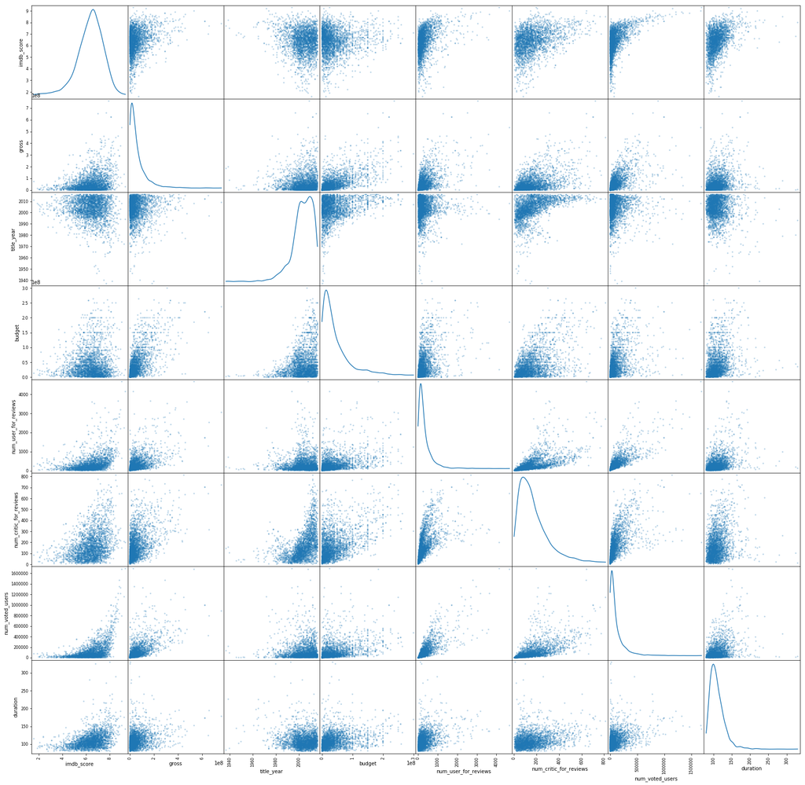

```python
# Here below are tools for anylising the data furthermore

# chosen features to anilyze further
features1 = ['imdb_score','gross','title_year', 'budget','num_user_for_reviews', 'num_critic_for_reviews', 'num_voted_users' ,'duration']
features2 = ['imdb_score','director_facebook_likes', 'actor_1_facebook_likes', 'actor_2_facebook_likes','actor_3_facebook_likes', 'cast_total_facebook_likes',]
df_descriptions1 = pd.DataFrame()
df_descriptions2 = pd.DataFrame()

df_descriptions1[features1] = df[features1]
df_descriptions2[features2] = df[features2]

# Scatter plot the data with the chosen features
pd.scatter_matrix(df_descriptions1, alpha = 0.3, figsize = (28,28), diagonal = 'kde');
display(df_descriptions1.describe())
```

|  | imdb_score | director_facebook_likes | actor_1_facebook_likes | actor_2_facebook_likes | actor_3_facebook_likes | cast_total_facebook_likes |
| --- | --- | --- | --- | --- | --- | --- |
| count | 2846.000000 | 2846.000000 | 2846.000000 | 2846.000000 | 2846.000000 | 2846.000000 |
| mean | 6.369325 | 883.628250 | 8503.491918 | 2259.200281 | 867.682713 | 12735.071328 |
| std | 1.047745 | 3269.145008 | 17097.701064 | 4914.515062 | 2059.883157 | 20856.846835 |
| min | 1.600000 | 0.000000 | 0.000000 | 0.000000 | 0.000000 | 0.000000 |
| 25% | 5.800000 | 12.000000 | 833.000000 | 458.250000 | 244.000000 | 2326.250000 |
| 50% | 6.500000 | 65.000000 | 2000.000000 | 746.500000 | 482.000000 | 4737.500000 |
| 75% | 7.100000 | 238.000000 | 13000.000000 | 1000.000000 | 729.750000 | 17363.500000 |
| max | 9.300000 | 23000.000000 | 640000.000000 | 137000.000000 | 23000.000000 | 656730.000000 |

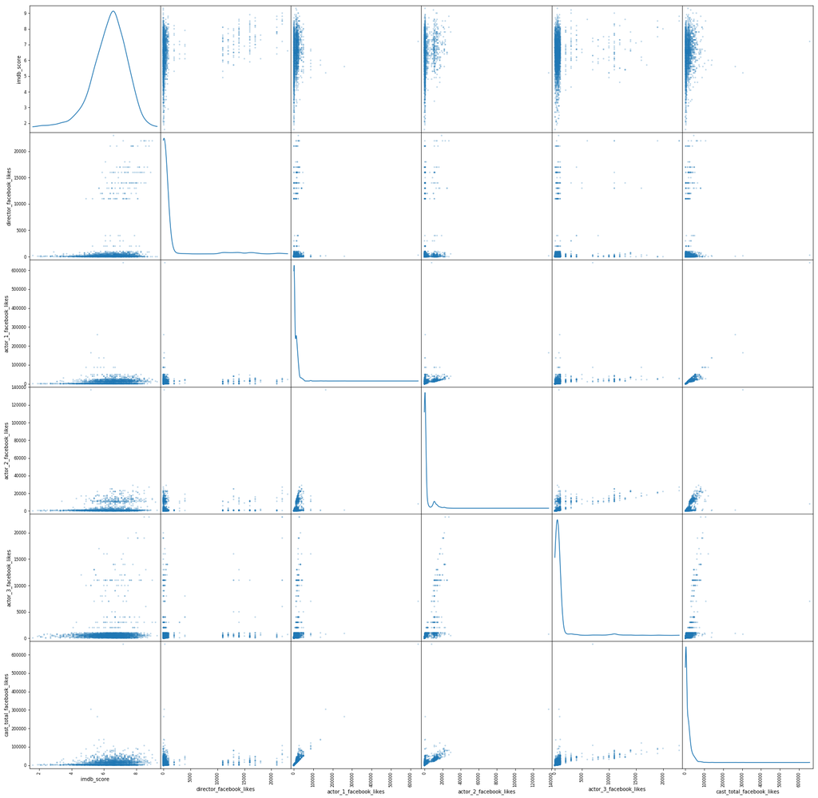

```python
# Next scatter matrix with fatures2 set earlier
pd.scatter_matrix(df_descriptions2, alpha = 0.3, figsize = (28,28), diagonal = 'kde');
display(df_descriptions2.describe())
```

Now lets take a look and the most relevant features e.g imdb score, facebook likes, title year and so on. Run the code below to display both a scatter plot of these relevant features as well as description of the data. When looking at the scatter plot, and going through imdb_score column it is noticible that there is some corrilation between imdb score and number of critics, votes, user reviews, gross and budget as well as some corrilation between social media and imdb score.

# Preproccessing the data

There are two columns that contains data that might consider valuable in predicting the score, that is 'genre' and 'content rating'. The genre is a string: Action|Adventure|Fantasy|Sci-Fi which label encoder will just take this as a string and give it a value, there are many variation of this string so if a movie that are considered similar in genre but dont have the same value, that will potentially corrupt the estimation. So to get the genre in better shape a code is written to extract each genre from each movie and add the value of that genres as a boolean value (0 or 1). Colums are created for each genres:

'Biography', 'Thriller', 'Comedy', 'Crime', 'Fantasy', 'Drama', 'Animation', 'Family', 'Action', 'Romance', 'Western', 'War', 'Adventure', 'Music', 'Horror', 'History', 'Sport', 'Musical', 'Documentary', 'Sci-Fi', 'Mystery' 'PG-13', 'PG', 'X', 'Approved', 'R', 'Passed', 'G', 'Not Rated', 'NC-17', 'M', 'Unrated'

Similar is done with content rating

PG-13', 'PG', 'X', 'Approved', 'R', 'Passed', 'G', 'Not Rated', 'NC-17', 'M', 'Unrated'

```python
# Extract all genres and store in the rows, comma seperated
all_rows_genre = df['genres'].str.rsplit(pat='|')

# Take all the rows and create a list of lists of all the plot key words
listOfList = []
for row in all_rows_genre:
    listOfList.append(row)


# Create a single list of all the words to extract only the unique words
flat_list = []
sublist = []
for n in range(len(listOfList)):
    sublist = listOfList[n]
    for j in sublist:
        flat_list.append(j)

# use set to extract unique words
uniqueSet = set(flat_list)
#  convert set to list
genres = list(uniqueSet)

# list of genres found in the data
# print(genres)

for genre in genres:
    df[genre] = df['genres'].str.contains(genre, regex=True).astype(int)

############

# Extract all content ratings and store in the rows, comma seperated
all_rows_content_rating = df['content_rating'].str.rsplit(pat='|')

# Take all the rows and create a list of lists of all the plot key words
listOfList = []
for row in all_rows_content_rating:
    listOfList.append(row)


# Create a single list of all the words to extract only the unique words
flat_list = []
sublist = []
for n in range(len(listOfList)):
    sublist = listOfList[n]
    for j in sublist:
        flat_list.append(j)

# use set to extract unique words
uniqueSet = set(flat_list)
#  convert set to list
content_ratings = list(uniqueSet)

#list of content ratings found in the data
# print(content_ratings)

#Next up is to put boolean in the specific content rating column if found
for content_rating in content_ratings:
    content_rating_name = 'content_rating{}'.format(content_rating)
    df[content_rating] = df['content_rating'].str.contains('^{}$'.format(content_rating), regex=True).astype(int)
display(df.head(n=5))
```

|  | color | director_name | num_critic_for_reviews | duration | director_facebook_likes | actor_3_facebook_likes | actor_2_name | actor_1_facebook_likes | gross | genres | ... | NC-17 | Approved | R | Unrated | G | PG-13 | Not Rated | Passed | PG | M |
| --- | --- | --- | --- | --- | --- | --- | --- | --- | --- | --- | --- | --- | --- | --- | --- | --- | --- | --- | --- | --- | --- |
| 0 | Color | James Cameron | 723.0 | 178.0 | 0.0 | 855.0 | Joel David Moore | 1000.0 | 760505847.0 | Action\|Adventure\|Fantasy\|Sci-Fi | ... | 0 | 0 | 0 | 0 | 0 | 1 | 0 | 0 | 0 | 0 |
| 1 | Color | Gore Verbinski | 302.0 | 169.0 | 563.0 | 1000.0 | Orlando Bloom | 40000.0 | 309404152.0 | Action\|Adventure\|Fantasy | ... | 0 | 0 | 0 | 0 | 0 | 1 | 0 | 0 | 0 | 0 |
| 3 | Color | Christopher Nolan | 813.0 | 164.0 | 22000.0 | 23000.0 | Christian Bale | 27000.0 | 448130642.0 | Action\|Thriller | ... | 0 | 0 | 0 | 0 | 0 | 1 | 0 | 0 | 0 | 0 |
| 5 | Color | Andrew Stanton | 462.0 | 132.0 | 475.0 | 530.0 | Samantha Morton | 640.0 | 73058679.0 | Action\|Adventure\|Sci-Fi | ... | 0 | 0 | 0 | 0 | 0 | 1 | 0 | 0 | 0 | 0 |
| 6 | Color | Sam Raimi | 392.0 | 156.0 | 0.0 | 4000.0 | James Franco | 24000.0 | 336530303.0 | Action\|Adventure\|Romance | ... | 0 | 0 | 0 | 0 | 0 | 1 | 0 | 0 | 0 | 0 |

5 rows × 60 columns

Now lets take a look at the data again. After a little bit of clean up, we end up with 2846 movies,

```python
# Total number of records
n_records = df.shape[0]

# Average score of the movies
average_score = np.sum(df['imdb_score'])/n_records

# Lowest score of movie
lowest_score = np.min(df['imdb_score'])

# Highest score of movie
highest_score = np.max(df['imdb_score'])


# Print the results
print("Total number of movies: {}".format(n_records))
print("Highest movie score: {}".format(highest_score))
print("Lowest movie score: {}".format(lowest_score))
print("Average score: {}".format(average_score))

# Total description
display(df.describe())
display(df.head(n=5))
```

```
Total number of movies: 2846
Highest movie score: 9.3
Lowest movie score: 1.6
Average score: 6.3693253689388625
```

|  | num_critic_for_reviews | duration | director_facebook_likes | actor_3_facebook_likes | actor_1_facebook_likes | gross | num_voted_users | cast_total_facebook_likes | facenumber_in_poster | num_user_for_reviews | ... | NC-17 | Approved | R | Unrated | G | PG-13 | Not Rated | Passed | PG | M |
| --- | --- | --- | --- | --- | --- | --- | --- | --- | --- | --- | --- | --- | --- | --- | --- | --- | --- | --- | --- | --- | --- |
| count | 2846.000000 | 2846.000000 | 2846.000000 | 2846.000000 | 2846.000000 | 2.846000e+03 | 2.846000e+03 | 2846.000000 | 2846.000000 | 2846.000000 | ... | 2846.000000 | 2846.000000 | 2846.000000 | 2846.000000 | 2846.000000 | 2846.000000 | 2846.000000 | 2846.000000 | 2846.00000 | 2846.000000 |
| mean | 167.972593 | 110.067112 | 883.628250 | 867.682713 | 8503.491918 | 5.961920e+07 | 1.101634e+05 | 12735.071328 | 1.427618 | 339.257906 | ... | 0.001054 | 0.002460 | 0.438159 | 0.003514 | 0.018623 | 0.373858 | 0.002811 | 0.000351 | 0.15636 | 0.000351 |
| std | 125.593931 | 21.688773 | 3269.145008 | 2059.883157 | 17097.701064 | 7.365131e+07 | 1.567310e+05 | 20856.846835 | 2.142104 | 404.382237 | ... | 0.032456 | 0.049542 | 0.496248 | 0.059183 | 0.135212 | 0.483912 | 0.052953 | 0.018745 | 0.36326 | 0.018745 |
| min | 2.000000 | 80.000000 | 0.000000 | 0.000000 | 0.000000 | 7.030000e+02 | 9.100000e+01 | 0.000000 | 0.000000 | 4.000000 | ... | 0.000000 | 0.000000 | 0.000000 | 0.000000 | 0.000000 | 0.000000 | 0.000000 | 0.000000 | 0.00000 | 0.000000 |
| 25% | 76.250000 | 96.000000 | 12.000000 | 244.000000 | 833.000000 | 1.326623e+07 | 2.141075e+04 | 2326.250000 | 0.000000 | 113.250000 | ... | 0.000000 | 0.000000 | 0.000000 | 0.000000 | 0.000000 | 0.000000 | 0.000000 | 0.000000 | 0.00000 | 0.000000 |
| 50% | 138.000000 | 106.000000 | 65.000000 | 482.000000 | 2000.000000 | 3.579660e+07 | 5.650500e+04 | 4737.500000 | 1.000000 | 211.500000 | ... | 0.000000 | 0.000000 | 0.000000 | 0.000000 | 0.000000 | 0.000000 | 0.000000 | 0.000000 | 0.00000 | 0.000000 |
| 75% | 225.000000 | 119.000000 | 238.000000 | 729.750000 | 13000.000000 | 7.765074e+07 | 1.360408e+05 | 17363.500000 | 2.000000 | 406.750000 | ... | 0.000000 | 0.000000 | 1.000000 | 0.000000 | 0.000000 | 1.000000 | 0.000000 | 0.000000 | 0.00000 | 0.000000 |
| max | 813.000000 | 330.000000 | 23000.000000 | 23000.000000 | 640000.000000 | 7.605058e+08 | 1.689764e+06 | 656730.000000 | 43.000000 | 4667.000000 | ... | 1.000000 | 1.000000 | 1.000000 | 1.000000 | 1.000000 | 1.000000 | 1.000000 | 1.000000 | 1.00000 | 1.000000 |

8 rows × 48 columns

|  | color | director_name | num_critic_for_reviews | duration | director_facebook_likes | actor_3_facebook_likes | actor_2_name | actor_1_facebook_likes | gross | genres | ... | NC-17 | Approved | R | Unrated | G | PG-13 | Not Rated | Passed | PG | M |
| --- | --- | --- | --- | --- | --- | --- | --- | --- | --- | --- | --- | --- | --- | --- | --- | --- | --- | --- | --- | --- | --- |
| 0 | Color | James Cameron | 723.0 | 178.0 | 0.0 | 855.0 | Joel David Moore | 1000.0 | 760505847.0 | Action\|Adventure\|Fantasy\|Sci-Fi | ... | 0 | 0 | 0 | 0 | 0 | 1 | 0 | 0 | 0 | 0 |
| 1 | Color | Gore Verbinski | 302.0 | 169.0 | 563.0 | 1000.0 | Orlando Bloom | 40000.0 | 309404152.0 | Action\|Adventure\|Fantasy | ... | 0 | 0 | 0 | 0 | 0 | 1 | 0 | 0 | 0 | 0 |
| 3 | Color | Christopher Nolan | 813.0 | 164.0 | 22000.0 | 23000.0 | Christian Bale | 27000.0 | 448130642.0 | Action\|Thriller | ... | 0 | 0 | 0 | 0 | 0 | 1 | 0 | 0 | 0 | 0 |
| 5 | Color | Andrew Stanton | 462.0 | 132.0 | 475.0 | 530.0 | Samantha Morton | 640.0 | 73058679.0 | Action\|Adventure\|Sci-Fi | ... | 0 | 0 | 0 | 0 | 0 | 1 | 0 | 0 | 0 | 0 |
| 6 | Color | Sam Raimi | 392.0 | 156.0 | 0.0 | 4000.0 | James Franco | 24000.0 | 336530303.0 | Action\|Adventure\|Romance | ... | 0 | 0 | 0 | 0 | 0 | 1 | 0 | 0 | 0 | 0 |

5 rows × 60 columns

## Preparing the data

- **country** : is taken out as we are only looking at movies in USA
- **language** : is take out as we are only looking at movies in English
- **movie_imdb_link** : is irrelevant, no need for url
- **movie_title** : nearly all movies have unique names so is irrelevant for the model
- **color** : is take out as we are only looking at movies in Color
- **facenumber_in_poster** : which actor is on the poster, it is registered as a number, many movies have many faces on their poster, this number only contains one number so this irrelevent for our model
- **plot_keywords** : This one is same with genres, it is a string with 5 plot keywords, but the bad thing is that these are around 1000 unique keywords
- **genres** : is taken out as we have already extracted all the genres and added it into new colums, so the overall genres list is take out.
- **content_rating** : similar with genres, we put all the genres in new columns

```python
# Drop columns as described
df.drop(['country', 'language', 'movie_imdb_link', 'movie_title', 'color', 'facenumber_in_poster', 'plot_keywords', 'genres', 'content_rating'], axis = 1, inplace = True)
display(df.head(n=5))
print(list(df.columns))
```

|  | director_name | num_critic_for_reviews | duration | director_facebook_likes | actor_3_facebook_likes | actor_2_name | actor_1_facebook_likes | gross | actor_1_name | num_voted_users | ... | NC-17 | Approved | R | Unrated | G | PG-13 | Not Rated | Passed | PG | M |
| --- | --- | --- | --- | --- | --- | --- | --- | --- | --- | --- | --- | --- | --- | --- | --- | --- | --- | --- | --- | --- | --- |
| 0 | James Cameron | 723.0 | 178.0 | 0.0 | 855.0 | Joel David Moore | 1000.0 | 760505847.0 | CCH Pounder | 886204 | ... | 0 | 0 | 0 | 0 | 0 | 1 | 0 | 0 | 0 | 0 |
| 1 | Gore Verbinski | 302.0 | 169.0 | 563.0 | 1000.0 | Orlando Bloom | 40000.0 | 309404152.0 | Johnny Depp | 471220 | ... | 0 | 0 | 0 | 0 | 0 | 1 | 0 | 0 | 0 | 0 |
| 3 | Christopher Nolan | 813.0 | 164.0 | 22000.0 | 23000.0 | Christian Bale | 27000.0 | 448130642.0 | Tom Hardy | 1144337 | ... | 0 | 0 | 0 | 0 | 0 | 1 | 0 | 0 | 0 | 0 |
| 5 | Andrew Stanton | 462.0 | 132.0 | 475.0 | 530.0 | Samantha Morton | 640.0 | 73058679.0 | Daryl Sabara | 212204 | ... | 0 | 0 | 0 | 0 | 0 | 1 | 0 | 0 | 0 | 0 |
| 6 | Sam Raimi | 392.0 | 156.0 | 0.0 | 4000.0 | James Franco | 24000.0 | 336530303.0 | J.K. Simmons | 383056 | ... | 0 | 0 | 0 | 0 | 0 | 1 | 0 | 0 | 0 | 0 |

5 rows × 51 columns

[output not shown]

## Encode

First thing first is to encode the data so that it can be used in the classifiers later on. [LabelEncoder](http://scikit-learn.org/stable/modules/preprocessing_targets.html) is a utility class to help normalize labels such that they contain only values between 0 and n_classes-1.

```python
# from sklearn import preprocessing
from sklearn.preprocessing import LabelEncoder
def dfToEncode(df_enc, y):
#     https://www.kaggle.com/pratsiuk/valueerror-unknown-label-type-continuous
    columnsToEncode = list(df_enc.select_dtypes(include=['category','object']))
    lab_enc = LabelEncoder()
    for feature in columnsToEncode:
        try:
            df_enc[feature] = lab_enc.fit_transform(df_enc[feature])
        except:
            print('Something went wrong with feature: ' + feature)
    y_enc = lab_enc.fit_transform(y)
    return df_enc, y_enc
```

Now the data will be encoded so that all strings are now numbers, i.e. director name for a movie is e.g. 438 and so on, this occurs for all the data that consists of strings.

## Shuffle and split the data

Next step is to implement shuffling, splitting, scaling and the desired learners for the data. First of there is necessary imports needed to import for all the classifiers, scaling and other things. The code below is several functions that will then be used later on, as the data will be analyzed further more. Run the code below

```python
# Necasary imports
from sklearn.cross_validation import train_test_split
from sklearn.tree import DecisionTreeRegressor
from sklearn import preprocessing
from sklearn.preprocessing import MinMaxScaler
from sklearn import utils
from sklearn.metrics import accuracy_score
from sklearn.svm import SVC
from sklearn.svm import LinearSVC
from sklearn.linear_model import LogisticRegression
from sklearn import tree
from sklearn.ensemble import RandomForestClassifier
from sklearn.metrics import r2_score
from sklearn.metrics import mean_squared_error
from math import sqrt
from sklearn.metrics import f1_score
```

```python
# A function that scales the numerical data with minMaxScaler, with the default values of (0,1)
def scaling(dataX):
    scaler = MinMaxScaler() # default=(0, 1)

    numerical = ['num_critic_for_reviews',
                 'director_facebook_likes', 'actor_3_facebook_likes',
                 'actor_1_facebook_likes', 'gross',
                 'num_voted_users', 'cast_total_facebook_likes',
                 'num_user_for_reviews', 'budget',
                 'actor_2_facebook_likes',
                 'movie_facebook_likes']

#     numerical = ['director_facebook_likes','actor_2_facebook_likes', 'actor_3_facebook_likes', 'actor_1_facebook_likes', 'cast_total_facebook_likes', 'budget','movie_facebook_likes']


    X = pd.DataFrame(data = dataX)
    X[numerical] = scaler.fit_transform(X[numerical])

    return X


def train_test(X,y):
    # Split the 'features' and 'imdb_score' data into training and testing sets
    X_train, X_test, y_train, y_test = train_test_split(X,
                                                        y,
                                                        test_size = 0.20,
                                                        random_state = 10)
    ##########

    # Show the results of the split
    print("Training/Testing set has {}/{} samples.".format(X_train.shape[0],X_test.shape[0]))
    print("------")

    linearSVM(X_train, X_test, y_train, y_test)
    svm(X_train, X_test, y_train, y_test)

    logsticRegressionDefault(X_train, X_test, y_train, y_test)
    logsticRegressionTuned(X_train, X_test, y_train, y_test)

    decisionTreeDefault(X_train, X_test, y_train, y_test)
    decisionTreeTuned(X_train, X_test, y_train, y_test)

    randomForrestDefault(X_train, X_test, y_train, y_test)
#     Uncomment randomForrestMaxFeatureTuner to run the code for the search of finding the best max_features parameter
#     randomForrestMaxFeatureTuner(X_train, X_test, y_train, y_test)
    randomForrestTuned(X_train, X_test, y_train, y_test)


# Linear SVM function
def linearSVM(X_train, X_test, y_train, y_test):


    SVMl_clf = LinearSVC()
    SVMl_clf.fit(X_train,y_train)
    y_pred = SVMl_clf.predict(X_test)
    f1score = f1_score(y_test,y_pred, average='micro')
    print("Linear SVM has the F1 score of: {}".format(f1score))

# SVM function
def svm(X_train, X_test, y_train, y_test):

    SVM_clf = SVC()
    SVM_clf.fit(X_train, y_train)
    y_pred = SVM_clf.predict(X_test)
    f1score = f1_score(y_test,y_pred, average='micro')
    print("SVM has the F1 score of: {}".format(f1score))


# Logistic Regression function
def logsticRegressionDefault(X_train, X_test, y_train, y_test):

    LRclf = LogisticRegression(random_state = 10)
    LRclf.fit(X_train,y_train)
    y_pred = LRclf.predict(X_test)
    f1score = f1_score(y_test,y_pred, average='micro')
    print("logstic Regression (Default Parameters) has the F1 score of: {}".format(f1score))


# Logistic Regression function
def logsticRegressionTuned(X_train, X_test, y_train, y_test):
    C_param_range = [0.001,0.01,0.1,1,10]
    i = 0
    score_max = 0
    for i in C_param_range:
        LRclf = LogisticRegression(penalty = 'l2', C=i, random_state = 10)

        LRclf.fit(X_train,y_train)
        y_pred = LRclf.predict(X_test)
        f1score = f1_score(y_test,y_pred, average='micro')

        if f1score> score_max:
                score_max = f1score
                i = i
    print("Logistic Regression (Tuned Parameters) has the F1 score of: {}, with C parameter of {}".format(score_max,i))


# DecisionTree function
def decisionTreeDefault(X_train, X_test, y_train, y_test):

    tree_clf = tree.DecisionTreeClassifier(random_state = 10)

    tree_clf.fit(X_train, y_train)
    y_pred = tree_clf.predict(X_test)
    f1score = f1_score(y_test,y_pred, average='micro')
    print("Decision Tree (Default Parameters) has the F1 score of: {}".format(f1score))


# DecisionTree function
def decisionTreeTuned(X_train, X_test, y_train, y_test):
    score_max = 0
    leaf_size_max =0
    sample_leaf_options = [2,5,10,20,40,80]
    for leaf_size in sample_leaf_options :
        tree_clf = tree.DecisionTreeClassifier(criterion = "gini",
                                               random_state = 10,
                                               min_samples_leaf=leaf_size)

        tree_clf.fit(X_train, y_train)
        y_pred = tree_clf.predict(X_test)
        f1score = f1_score(y_test,y_pred, average='micro')

        if f1score> score_max:
            score_max = f1score
            leaf_size_max = leaf_size
    print("Decision Tree (Tuned Parameters) has the F1 score of: {}, with leaf size of: {}".format(score_max,leaf_size_max))



# Random forrest function
def randomForrestDefault(X_train, X_test, y_train, y_test):

    RF_clf = RandomForestClassifier(random_state =10)
    RF_clf = RF_clf.fit(X_train, y_train)
    y_pred = RF_clf.predict(X_test)
    f1score = f1_score(y_test,y_pred, average='micro')

    print("Random Forrest (Default Parameters) has the F1 score of: {}".format(f1score))



# Random forrest function
def randomForrestMaxFeatureTuner(X_train, X_test, y_train, y_test):
    score_max = 0
    max_feature =0
    max_feature_options = [0.1,0.2,0.3,0.4,0.5,0.6,0.7,0.8,0.9,'sqrt','log2']
    leaf_size_max =0
    sample_leaf_options = [1,2,3,4,5]
    for leaf_size in sample_leaf_options :
        for i in max_feature_options :
            RF_clf = RandomForestClassifier(n_estimators = 300,
                                            criterion='gini',
                                            oob_score = False,
                                            n_jobs = -1,
                                            random_state =10,
                                            max_features = i,
                                            min_samples_leaf = leaf_size)
            RF_clf = RF_clf.fit(X_train, y_train)
            y_pred = RF_clf.predict(X_test)
            f1score = f1_score(y_test,y_pred, average='micro')

            if f1score> score_max:
                score_max = f1score
                max_feature = i
                leaf_size_max = leaf_size
    print("Random Forrest (optimizing max feature) has the F1 score of: {}, with max_feature: {}, leaf size: {}".format(f1score, i, leaf_size_max))



# Random forrest function
def randomForrestTuned(X_train, X_test, y_train, y_test):
    score_max = 0
    leaf_size_max =0
    sample_leaf_options = [1,2,3,4,5]
    for leaf_size in sample_leaf_options :
        RF_clf = RandomForestClassifier(n_estimators = 300,
                                        criterion='gini',
                                        oob_score = False,
                                        n_jobs = -1,
                                        random_state =10,
                                        max_features = 'log2',
                                        min_samples_leaf = leaf_size)
        RF_clf = RF_clf.fit(X_train, y_train)
        y_pred = RF_clf.predict(X_test)
        f1score = f1_score(y_test,y_pred, average='micro')

        if f1score> score_max:
            score_max = f1score
            leaf_size_max = leaf_size
    print("Random Forrest (Tuned Parameters) has the F1 score of: {}, with leaf size of: {}".format(score_max,leaf_size_max))
```

## Evaluating Model Performance

The data consists of 2846 movies. Now lets evaluate the performance of the model by computing the score by using the implemented estimators and let's use that as a benchmark for later use. Run the code below.

```python
# Run this code to generate score for all the movies in the subset.
df_subset = df
y = df_subset['imdb_score']
df_encoded, y_encoded = dfToEncode(df_subset,y)

X = df_encoded.drop(['imdb_score'], axis = 1)
# Call scaling function
X = scaling(X)

y = np.array(y_encoded)
# Round the number to an even number, if the movie has
# 5.5 it rounds down to 5, if it has 5.6 it rounds up to 6
y = np.round(y/10)

print('Predicting movie score with all movies:')
train_test(X,y)
```

```
Predicting movie score with all movies:
Training/Testing set has 2276/570 samples.
------
Linear SVM has the F1 score of: 0.3508771929824561
SVM has the F1 score of: 0.375438596491228
logstic Regression (Default Parameters) has the F1 score of: 0.512280701754386
Logistic Regression (Tuned Parameters) has the F1 score of: 0.531578947368421, with C parameter of 10
Decision Tree (Default Parameters) has the F1 score of: 0.43859649122807015
Decision Tree (Tuned Parameters) has the F1 score of: 0.5140350877192983, with leaf size of: 40
Random Forrest (Default Parameters) has the F1 score of: 0.5491228070175439
Random Forrest (Tuned Parameters) has the F1 score of: 0.6, with leaf size of: 2
```

# Exploring the data further

Now what would happen if we take a look at all these features listed in this scatter plot and run the estimators again but this time we take a look at the data above the mean i.e. choose movies that are above mean in these chosen feature. Run the code below and lets take a look at what happens.

```python
# Run this code to generate score for the lis of features set in 'feature' here below. T

features = ['imdb_score','gross','title_year',
            'budget','num_user_for_reviews', 'num_critic_for_reviews',
            'num_voted_users' ,'duration', 'director_facebook_likes',
            'actor_1_facebook_likes', 'actor_2_facebook_likes',
            'actor_3_facebook_likes', 'cast_total_facebook_likes',
            'movie_facebook_likes']


for feature in features:

    df_subset = df[df[feature] > np.mean(df[feature])]

    y = df_subset['imdb_score']
    df_encoded, y_encoded = dfToEncode(df_subset,y)

    # Define X without imdb score
    X = df_encoded.drop(['imdb_score'], axis = 1)
    # Call scaling function
    X = scaling(X)

    y = np.array(y_encoded)
    # Round the number to an even number, if the movie has 5.5 it rounds down to 5, if it has 5.6 it rounds up to 6
    y = np.round(y/10)

    print('--------------------------------------------------------------------------------------')
    print('Predicting movie score with movies that is above mean in the feature: {}'.format(feature))
    train_test(X,y)
    print('--------------------------------------------------------------------------------------')
```

```
--------------------------------------------------------------------------------------
Predicting movie score with movies that is above mean in the feature: imdb_score
Training/Testing set has 1252/313 samples.
------
Linear SVM has the F1 score of: 0.4536741214057508
SVM has the F1 score of: 0.476038338658147
logstic Regression (Default Parameters) has the F1 score of: 0.5654952076677316
Logistic Regression (Tuned Parameters) has the F1 score of: 0.6006389776357828, with C parameter of 10
Decision Tree (Default Parameters) has the F1 score of: 0.610223642172524
Decision Tree (Tuned Parameters) has the F1 score of: 0.6421725239616614, with leaf size of: 40
Random Forrest (Default Parameters) has the F1 score of: 0.6230031948881789
Random Forrest (Tuned Parameters) has the F1 score of: 0.6517571884984026, with leaf size of: 3
--------------------------------------------------------------------------------------
--------------------------------------------------------------------------------------
Predicting movie score with movies that is above mean in the feature: gross
Training/Testing set has 752/188 samples.
------
Linear SVM has the F1 score of: 0.3191489361702128
SVM has the F1 score of: 0.4308510638297872
logstic Regression (Default Parameters) has the F1 score of: 0.5
Logistic Regression (Tuned Parameters) has the F1 score of: 0.526595744680851, with C parameter of 10
Decision Tree (Default Parameters) has the F1 score of: 0.5372340425531915
Decision Tree (Tuned Parameters) has the F1 score of: 0.5212765957446809, with leaf size of: 2
Random Forrest (Default Parameters) has the F1 score of: 0.526595744680851
Random Forrest (Tuned Parameters) has the F1 score of: 0.6542553191489362, with leaf size of: 1
--------------------------------------------------------------------------------------
--------------------------------------------------------------------------------------
Predicting movie score with movies that is above mean in the feature: title_year
Training/Testing set has 1238/310 samples.
------
Linear SVM has the F1 score of: 0.45161290322580644
SVM has the F1 score of: 0.46774193548387094
logstic Regression (Default Parameters) has the F1 score of: 0.4967741935483871
Logistic Regression (Tuned Parameters) has the F1 score of: 0.5161290322580645, with C parameter of 10
Decision Tree (Default Parameters) has the F1 score of: 0.4741935483870967
Decision Tree (Tuned Parameters) has the F1 score of: 0.5387096774193548, with leaf size of: 10
Random Forrest (Default Parameters) has the F1 score of: 0.49032258064516127
Random Forrest (Tuned Parameters) has the F1 score of: 0.5741935483870968, with leaf size of: 2
--------------------------------------------------------------------------------------
--------------------------------------------------------------------------------------
```

[output cut: 127 more lines]

```
Random Forrest (Tuned Parameters) has the F1 score of: 0.7, with leaf size of: 2
--------------------------------------------------------------------------------------
--------------------------------------------------------------------------------------
Predicting movie score with movies that is above mean in the feature: movie_facebook_likes
Training/Testing set has 652/164 samples.
------
Linear SVM has the F1 score of: 0.3170731707317073
SVM has the F1 score of: 0.40853658536585363
logstic Regression (Default Parameters) has the F1 score of: 0.5304878048780488
Logistic Regression (Tuned Parameters) has the F1 score of: 0.5853658536585366, with C parameter of 10
Decision Tree (Default Parameters) has the F1 score of: 0.5792682926829268
Decision Tree (Tuned Parameters) has the F1 score of: 0.6219512195121951, with leaf size of: 20
Random Forrest (Default Parameters) has the F1 score of: 0.5914634146341463
Random Forrest (Tuned Parameters) has the F1 score of: 0.6707317073170732, with leaf size of: 3
--------------------------------------------------------------------------------------
```

# Feature Importance

Here below is feature importance visulazation, run the code below to plot the feature importance

```
Feature ranking:
1. feature 9 (0.088912)
2. feature 12 (0.062828)
3. feature 2 (0.058099)
4. feature 13 (0.054008)
5. feature 7 (0.051167)
6. feature 1 (0.050978)
7. feature 14 (0.046510)
8. feature 10 (0.043224)
9. feature 3 (0.042848)
10. feature 5 (0.042823)
11. feature 0 (0.042633)
12. feature 8 (0.042437)
13. feature 11 (0.042023)
14. feature 4 (0.041495)
15. feature 17 (0.040178)
16. feature 15 (0.039867)
17. feature 6 (0.038656)
18. feature 23 (0.022629)
19. feature 16 (0.012450)
20. feature 30 (0.011729)
21. feature 37 (0.010578)
22. feature 45 (0.010437)
23. feature 35 (0.009481)
24. feature 42 (0.009170)
25. feature 20 (0.007951)
26. feature 22 (0.007558)
27. feature 34 (0.007435)
28. feature 31 (0.007113)
29. feature 36 (0.006913)
30. feature 21 (0.006850)
31. feature 48 (0.005449)
32. feature 32 (0.004562)
33. feature 29 (0.004457)
34. feature 33 (0.004336)
35. feature 24 (0.003696)
36. feature 27 (0.003691)
37. feature 19 (0.002935)
38. feature 26 (0.002027)
39. feature 28 (0.002025)
40. feature 18 (0.002006)
41. feature 25 (0.001881)
42. feature 38 (0.001394)
43. feature 44 (0.001186)
44. feature 41 (0.000407)
45. feature 46 (0.000336)
46. feature 39 (0.000290)
47. feature 43 (0.000237)
48. feature 40 (0.000054)
49. feature 49 (0.000053)
50. feature 47 (0.000000)
```

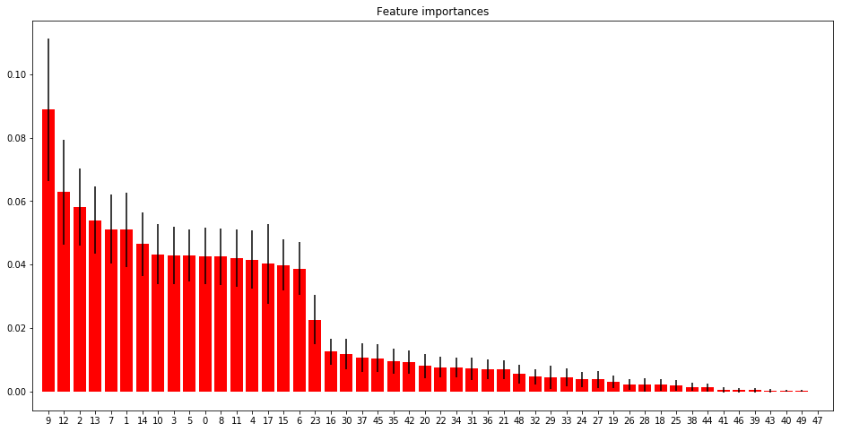

```
                           importance
num_voted_users              0.088912
num_user_for_reviews         0.062828
duration                     0.058099
budget                       0.054008
gross                        0.051167
num_critic_for_reviews       0.050978
title_year                   0.046510
cast_total_facebook_likes    0.043224
director_facebook_likes      0.042848
actor_2_name                 0.042823
director_name                0.042633
actor_1_name                 0.042437
actor_3_name                 0.042023
actor_3_facebook_likes       0.041495
movie_facebook_likes         0.040178
actor_2_facebook_likes       0.039867
actor_1_facebook_likes       0.038656
Drama                        0.022629
aspect_ratio                 0.012450
Comedy                       0.011729
Action                       0.010578
PG-13                        0.010437
Thriller                     0.009481
R                            0.009170
Horror                       0.007951
Crime                        0.007558
Romance                      0.007435
Fantasy                      0.007113
Adventure                    0.006913
Sci-Fi                       0.006850
PG                           0.005449
Mystery                      0.004562
Biography                    0.004457
Family                       0.004336
Music                        0.003696
Animation                    0.003691
Sport                        0.002935
Musical                      0.002027
Documentary                  0.002025
History                      0.002006
War                          0.001881
Western                      0.001394
G                            0.001186
Approved                     0.000407
Not Rated                    0.000336
X                            0.000290
Unrated                      0.000237
NC-17                        0.000054
M                            0.000053
Passed                       0.000000
```

```python
import matplotlib.pyplot as plt

# Run this code to generate score for all the movies in the subset.
df_subset = df
y = df_subset['imdb_score']
df_encoded, y_encoded = dfToEncode(df_subset,y)

X = df_encoded.drop(['imdb_score'], axis = 1)
# Call scaling function
X = scaling(X)

y = np.array(y_encoded)
# Round the number to an even number, if the movie has
# 5.5 it rounds down to 5, if it has 5.6 it rounds up to 6
y = np.round(y/10)

X_train, X_test, y_train, y_test = train_test_split(X,
                                                    y,
                                                    test_size = 0.20,
                                                    random_state = 10)


RF_clf = RandomForestClassifier(n_estimators = 300,
                                criterion='gini',
                                oob_score = False,
                                n_jobs = -1,
                                random_state =10,
                                max_features = 'log2')
RF_clf = RF_clf.fit(X_train, y_train)


feature_importance = RF_clf.feature_importances_
std = np.std([tree.feature_importances_ for tree in RF_clf.estimators_],
             axis=0)
indices = np.argsort(feature_importance)[::-1]

# Print the feature ranking
print("Feature ranking:")
for f in range(X.shape[1]):
    print("%d. feature %d (%f)" % (f + 1, indices[f], feature_importance[indices[f]]))

# Plot the feature importances of the forest
plt.figure(figsize = (16,8))
plt.title("Feature importances")
plt.bar(range(X.shape[1]), feature_importance[indices],
       color="r", yerr=std[indices], align="center")
plt.xticks(range(X.shape[1]), indices)
plt.xlim([-1, X.shape[1]])
plt.show()

# Print list of the importance but now with the feature name
feature_importances = pd.DataFrame(RF_clf.feature_importances_,
                                   index = X_train.columns,
                                   columns=['importance']).sort_values('importance', ascending=False)
print(feature_importances)
```

# Conclusion